# Final Tutorial - Global Terrorism Data Analysis

## Introduction

In this tutorial, you will apply data science to explore correlations that exist within global terrorism data, using the Global Terrorism Database maintained by the START consortium. We will first visualize the global data in various ways to form a better intuition on possible correlations that may exist. Using compiled features such as date and location, we will hypothesize what related factors may play a role in determining the likelihood of a terrorist attack and cross reference data outside the original dataset to test our hypotheses.

## Getting Started

Before you begin, you will need to install a few libraries. First, confirm you have the python package manager 'pip' installed on your computer. Installation instructions can be found online.

You will first need to download the dataset from https://www.kaggle.com/START-UMD/gtd. This dataset contains information on terrorist attacks from around the world and it contains more than 170,000 cases. All credit for the dataset goes to the researchers at the National Consortium for the Study of Terrorism and Responses to Terrorism (START). More information on their organization can be found here: http://start.umd.edu/gtd/.

This tutorial will be working with a dataset in the form of a CSV (comma separated value) file.

### Installing Packages

Before beginning you must install all required packages:

- numpy
- matplotlib
- pandas
- folium
- seaborn
- sklearn
- statsmodels

If any are missing you may install them through your computer's shell or directly through this tutorial using the script below.

```python
%%capture
import pip
def install(package):
   pip.main(['install', package])

install('numpy')
install('matplotlib')
install('pandas')
install('folium')
install('seabord')
install('sklearn')
install('statsmodels')
```

### Importing Packages

Now that we have the packages we need we can import and alias them for this tutorial

```python
import pandas as pd, numpy as np
import matplotlib.pyplot as plt, seaborn as sns
import csv, folium, math
from datetime import datetime
from folium.plugins import HeatMap, HeatMapWithTime
%matplotlib inline
```

# I. Data Collection and Processing

## Cleaning

We want to pull in our global terrorism data as a pandas dataframe to begin

```python
# Open  file and extract csv data
gtd_table = pd.read_csv("globalterrorismdb_0617dist.csv", encoding='latin1', low_memory=False)

gtd_table.head()
```

|  | eventid | iyear | imonth | iday | approxdate | extended | resolution | country | country_txt | region | ... | addnotes | scite1 | scite2 | scite3 | dbsource | INT_LOG | INT_IDEO | INT_MISC | INT_ANY | related |
| --- | --- | --- | --- | --- | --- | --- | --- | --- | --- | --- | --- | --- | --- | --- | --- | --- | --- | --- | --- | --- | --- |
| 0 | 1.970000e+11 | 1970 | 7 | 2 | NaN | 0 | NaN | 58 | Dominican Republic | 2 | ... | NaN | NaN | NaN | NaN | PGIS | 0 | 0 | 0 | 0 | NaN |
| 1 | 1.970000e+11 | 1970 | 0 | 0 | NaN | 0 | NaN | 130 | Mexico | 1 | ... | NaN | NaN | NaN | NaN | PGIS | 0 | 1 | 1 | 1 | NaN |
| 2 | 1.970010e+11 | 1970 | 1 | 0 | NaN | 0 | NaN | 160 | Philippines | 5 | ... | NaN | NaN | NaN | NaN | PGIS | -9 | -9 | 1 | 1 | NaN |
| 3 | 1.970010e+11 | 1970 | 1 | 0 | NaN | 0 | NaN | 78 | Greece | 8 | ... | NaN | NaN | NaN | NaN | PGIS | -9 | -9 | 1 | 1 | NaN |
| 4 | 1.970010e+11 | 1970 | 1 | 0 | NaN | 0 | NaN | 101 | Japan | 4 | ... | NaN | NaN | NaN | NaN | PGIS | -9 | -9 | 1 | 1 | NaN |

5 rows × 135 columns

### Selecting Desired Columns

The columns we are interested in looking at are the ones containing time and location data. We'll save the eventid and attacktype1 along with the time/location columns in case we find a need for it later. Once we've selected our columns we'll rename them for readability.

```python
# Retrieve desirable columns
column_names = ['eventid', 'iyear', 'imonth', 'iday', 'country_txt', 'provstate', 'city', 'latitude', 'longitude', 'attacktype1_txt']
gtd_table = gtd_table[column_names]

# Rename columns
new_column_names = ['id', 'year', 'month', 'day', 'country', 'provstate', 'city', 'latitude', 'longitude', 'attacktype']
gtd_table.columns = new_column_names
```

### Modifying Faulty Entries

```python
gtd_table.describe()
```

|  | id | year | month | day | latitude | longitude |
| --- | --- | --- | --- | --- | --- | --- |
| count | 1.703500e+05 | 170350.000000 | 170350.000000 | 170350.000000 | 165744.000000 | 165744.000000 |
| mean | 2.001775e+11 | 2001.709997 | 6.474365 | 15.466845 | 23.399774 | 26.350909 |
| std | 1.314443e+09 | 13.144146 | 3.392364 | 8.817929 | 18.844885 | 58.570068 |
| min | 1.970000e+11 | 1970.000000 | 0.000000 | 0.000000 | -53.154613 | -176.176447 |
| 25% | 1.990050e+11 | 1990.000000 | 4.000000 | 8.000000 | 11.263580 | 2.396199 |
| 50% | 2.007120e+11 | 2007.000000 | 6.000000 | 15.000000 | 31.472680 | 43.130000 |
| 75% | 2.014020e+11 | 2014.000000 | 9.000000 | 23.000000 | 34.744167 | 68.451297 |
| max | 2.017010e+11 | 2016.000000 | 12.000000 | 31.000000 | 74.633553 | 179.366667 |

Looking at the table above we see that there are entries where the month, day, or both are logged as 0. Upon inspection we see see that when either descriptor is 0 the associated entry is either incomplete or an attack that spanned multiple days. Since either scenario can be unreliable for temporal data analysis, we will drop any rows containing a 0 in either column.

```python
gtd_table = gtd_table[gtd_table.month != 0]
gtd_table = gtd_table[gtd_table.day != 0]
gtd_table = gtd_table.reset_index(drop=True)
```

The other column we would like to have is a date column that has the collective year-month of an event so that we can more easily create generate a graphp grouped by this column

```python
gtd_table['date'] = gtd_table.apply(lambda row: '%d-%02d' %(row.year, row.month), axis=1)
```

Now, there are two additional columns we want to create to make our exploratory analysis easier. The first is a column indicating the day of the year that the event occured. Using this we can more easily generate time-dependent imaging of the occurence of events. We save this value as a single integer.

```python
# Converting year, month, day columns to days of year
daysofyear = []
months = []
days = []
for index,row in gtd_table.iterrows():
    year = row['year']
    month = row['month']
    day = row['day']
    daysofyear.append(datetime(year,month,day).timetuple().tm_yday)
    months.append(month)
    days.append(day)
gtd_table['dayofyear'] = daysofyear
gtd_table.head()
```

|  | id | year | month | day | country | provstate | city | latitude | longitude | attacktype | date | dayofyear |
| --- | --- | --- | --- | --- | --- | --- | --- | --- | --- | --- | --- | --- |
| 0 | 1.970000e+11 | 1970 | 7 | 2 | Dominican Republic | NaN | Santo Domingo | 18.456792 | -69.951164 | Assassination | 1970-07 | 183 |
| 1 | 1.970010e+11 | 1970 | 1 | 1 | United States | Illinois | Cairo | 37.005105 | -89.176269 | Armed Assault | 1970-01 | 1 |
| 2 | 1.970010e+11 | 1970 | 1 | 2 | Uruguay | Montevideo | Montevideo | -34.891151 | -56.187214 | Assassination | 1970-01 | 2 |
| 3 | 1.970010e+11 | 1970 | 1 | 2 | United States | California | Oakland | 37.805065 | -122.273024 | Bombing/Explosion | 1970-01 | 2 |
| 4 | 1.970010e+11 | 1970 | 1 | 2 | United States | Wisconsin | Madison | 43.076592 | -89.412488 | Facility/Infrastructure Attack | 1970-01 | 2 |

# II. Exploratory Data Analysis and Visualization

## Temporal Data Visualization

### Chronological Counts by Month

Now that we have our desired columns let's take a look at the occurences of global terrorist attacks by month.

```python
# Group table by date into counts
glo_chm = gtd_table[['date','id']].groupby(['date']).count()
glo_chm = glo_chm.rename(index=str, columns={'id':'count'})
glo_chm = glo_chm.reset_index()
glo_chm.head()
```

|  | date | count |
| --- | --- | --- |
| 0 | 1970-01 | 36 |
| 1 | 1970-02 | 55 |
| 2 | 1970-03 | 68 |
| 3 | 1970-04 | 78 |
| 4 | 1970-05 | 70 |

We'll first want to establish some properly spaced labels from the data we have in order ot make our graph more readable. Then we can generate our graph.

```python
yearmax = gtd_table['year'].max()
yearmin = gtd_table['year'].min()
numyears = yearmax - yearmin + 1
year_labels = range(yearmin, yearmax+1, 5)
year_ticks = [60*i for i in range(int(numyears/5)+1)]
```

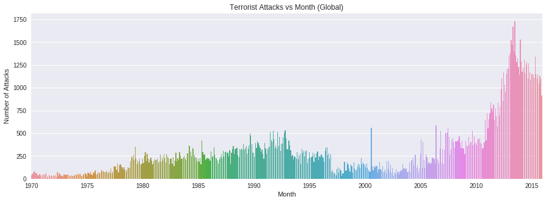

```python
# Graph and label figure
fig, ax = plt.subplots(figsize=(15,5))
sns.barplot(x='date',y='count',data=glo_chm)
plt.title('Terrorist Attacks vs Month (Global)')
plt.ylabel('Number of Attacks')
plt.xlabel('Month')
plt.xticks(year_ticks);
ax.set_xticklabels(year_labels);
```

### Chronological Counts by Year

Let's try organizing the chronological data of attacks by year rather than month to make our visualization easier to understand.

```python
# Group table by date into counts
glo_chy = gtd_table[['year','id']].groupby(['year']).count()
glo_chy = glo_chy.rename(index=str, columns={'id':'count'})
glo_chy = glo_chy.reset_index()
glo_chy.head()
```

|  | year | count |
| --- | --- | --- |
| 0 | 1970 | 636 |
| 1 | 1971 | 460 |
| 2 | 1972 | 489 |
| 3 | 1973 | 463 |
| 4 | 1974 | 571 |

```python
# Establish ticks and labels for this type of graph
year_labels2 = range(yearmin, yearmax+1, 5)
year_ticks2 = [5*i for i in range(int(numyears/5)+1)]
```

We'll first want to establish some properly spaced labels from the data we have in order ot make our graph more readable. Then we can generate our graph.

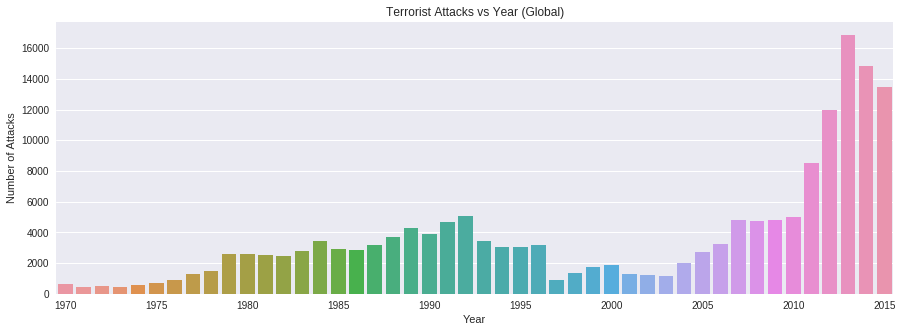

```python
# Graph and label figure
fig, ax = plt.subplots(figsize=(15,5))
sns.barplot(x='year',y='count',data=glo_chy)
plt.title('Terrorist Attacks vs Year (Global)')
plt.ylabel('Number of Attacks')
plt.xlabel('Year')
plt.xticks(year_ticks2);
ax.set_xticklabels(year_labels2);
```

We can now get a broader picture on some trends on terrorist attacks across time. Exploring data and ensuring that you have the right scale and metrics is important to ease the process of data exploration.

## Spatial Data Visualization

Now that we've explored the temporal side of the data, lets now transition to the spatial aspect. We can use the folium package to output a map using the coordinates provided with the data. First, recall the stats of the dataset.

```python
gtd_table.describe()
```

|  | id | year | month | day | latitude | longitude | dayofyear |
| --- | --- | --- | --- | --- | --- | --- | --- |
| count | 1.694590e+05 | 169459.000000 | 169459.000000 | 169459.000000 | 164941.000000 | 164941.000000 | 169459.000000 |
| mean | 2.001842e+11 | 2001.777132 | 6.474616 | 15.548168 | 23.404921 | 26.454261 | 181.491482 |
| std | 1.311624e+09 | 13.115980 | 3.390868 | 8.769280 | 18.832724 | 58.524152 | 103.643982 |
| min | 1.970000e+11 | 1970.000000 | 1.000000 | 1.000000 | -53.154613 | -176.176447 | 1.000000 |
| 25% | 1.990060e+11 | 1990.000000 | 4.000000 | 8.000000 | 11.280768 | 2.705000 | 93.000000 |
| 50% | 2.008010e+11 | 2008.000000 | 6.000000 | 15.000000 | 31.472680 | 43.130000 | 181.000000 |
| 75% | 2.014030e+11 | 2014.000000 | 9.000000 | 23.000000 | 34.730833 | 68.495925 | 271.000000 |
| max | 2.017010e+11 | 2016.000000 | 12.000000 | 31.000000 | 74.633553 | 179.366667 | 366.000000 |

As you can see we have around 170k lines of data to plot on our spatial map. The juypter notebook will cap the amount of data points being rendered onto the map, so to prevent this we will take a sample of 1000 points from our data. The folium.HeatMap plugin takes in points in the form of a list of lists containing [{latiitude},{longitude}].

```python
gtd_table_sample = gtd_table.sample(n=1000, axis=0)
heatmap_data = [gtd_table_sample['latitude'].dropna(), gtd_table_sample['longitude'].dropna()]
heatmap_data = np.rot90(heatmap_data, k=1)
heatmap_data = heatmap_data.tolist()
```

Now we can initialize the heatmap by stating the starding coordinates and adding our heatmap data to the heatmap.

Note: If the heatmap does not show up, try disabling popup blocker or ad blocker prior to viewing this page.

```python
m = folium.Map([0.0, 0.0], tiles='stamentoner', zoom_start=2.4)
HeatMap(heatmap_data).add_to(m)
m
```

[interactive chart not shown]

Looking at our heatmap we can see where most terrorist attacks are occuring. Because we have the data on the country for each attack, we can filter out our data based on country and create a heatmap for each country. For now, lets create a heatmap of all the terrorist attacks occuring in the US. We do this by creating a new list of data then recompiling a list of the coordinate data for the filtered list.

```python
gtd_table_sample_us = gtd_table.loc[gtd_table['country'] == 'United States']
heatmap_data_us = [gtd_table_sample_us['latitude'].dropna(), gtd_table_sample_us['longitude'].dropna()]
heatmap_data_us = np.rot90(heatmap_data_us, k=1)
heatmap_data_us = heatmap_data_us.tolist()
print('Number of Entries: '+str(len(heatmap_data)))
```

```
Number of Entries: 977
```

```python
us_heatmap = folium.Map([37.0902, -95.7129], tiles='stamentoner', zoom_start=4)
HeatMap(heatmap_data_us).add_to(us_heatmap)
us_heatmap
```

[interactive chart not shown]

Looking at the map we can easily see where the terrorists attacks have been occuring in the US. What if we wanted to go further and look at when these attacks have been occuring?

## Temporal + Geospatial Data Visualization

Because our table contains data on the month of the attack, we can utilize this to create a heatmap with a time factor. We do this by using the folium plugin called HeatMapWithTime. Remember the heatmap data we used to create the heeatmap? This plugin requires a list of heatmap data, so we will need to construct a 3-D list of coordinate data. First lets create a new list to represent each month of the year using numpy.

```python
months = np.arange(1,13)
```

Then we can iterate through each row of the US data and check its month to add that data to its respective month.

```python
data = []
for month in months:
    month_slot = []
    for index, row in gtd_table_sample_us.iterrows():
        if row['month'] == month and not math.isnan(row['latitude']):
            month_slot.append([row['latitude'], row['longitude']])
    data.append(month_slot)
```

Finally we add this heatmap data with time into a new folium heatmap.

```python
us_heatmap_month = folium.Map([37.0902, -95.7129], tiles='stamentoner', zoom_start=4)
HeatMapWithTime(data,auto_play=True).add_to(us_heatmap_month)
us_heatmap_month
```

[interactive chart not shown]

(If the map does not render, try disabling popup blocker then refreshing the page!)

Now we can see our US heatmap data separated by month. We have now made it a lot easier to differentiate between the time of year and the location of the terrorist attack, so we can now easily make observations based on this visualization.

Python has many powerful tools used for data visualization, and we highly recommend you to explore them all

# III. Analysis and Machine Learning

Now that we've explored our data through different visualizations, we can now perform analysis of our data through machine learning. Machine learning relates to finding patterns in data and using those patterns to make predictions of past or future values and draw conclusions from them. Our first step in our analysis will be to decide which variable to predict.

## Counts by Day of the Year

Now let's generate a graph using our day of the year column. We can check for any trends in activity throughout the year.

```python
table_by_date = gtd_table[['dayofyear','id']].groupby(['dayofyear']).count()
table_by_date = table_by_date.rename(index=str, columns={'id':'count'})
table_by_date = table_by_date.reset_index()
table_by_date.head()
```

|  | dayofyear | count |
| --- | --- | --- |
| 0 | 1 | 584 |
| 1 | 2 | 388 |
| 2 | 3 | 496 |
| 3 | 4 | 496 |
| 4 | 5 | 421 |

Like before, we want to generate some appropriate markers for our x-axis. Otherwise the data will be difficult to read.

```python
month_labels = ['JAN','FEB','MAR','APR','MAY','JUN','JUL','AUG','SEP','OCT','NOV','DEC']
month_ticks = []
for i in range(12):
    month_ticks.append(datetime(2000,i+1,1).timetuple().tm_yday)
```

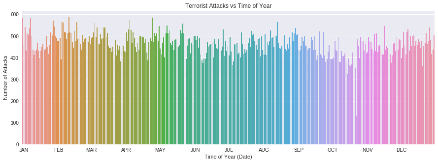

```python
fig, ax = plt.subplots(figsize=(15,5))
sns.barplot(x='dayofyear',y='count',data=table_by_date);
plt.title('Terrorist Attacks vs Time of Year')
plt.ylabel('Number of Attacks')
plt.xlabel('Time of Year (Date)')
plt.xticks(month_ticks);
ax.set_xticklabels(month_labels);
```

## Stratifying by Country

Every day is a holiday somewhere. In order to draw a more meaningful correlation we could try narrowing down our analysis to a single country. Since the U.S. seems to have the largest dataset of reported terrorist attacks we can focus on it as well as the national and religious holidays observed in the country.

We'll start with the chronological data as before, this time grouping the analysis by year from the start since the data is easier to interpret.

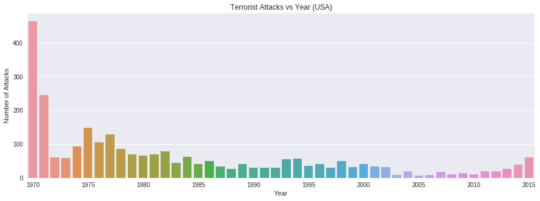

```python
# Group table by date into counts
usa_chy = gtd_table.loc[gtd_table['country'] == 'United States']
usa_chy = usa_chy[['year','id']].groupby(['year']).count()
usa_chy = usa_chy.rename(index=str, columns={'id':'count'})
usa_chy = usa_chy.reset_index()

# Graph and label figure
fig, ax = plt.subplots(figsize=(15,5))
sns.barplot(x='year',y='count',data=usa_chy)
plt.title('Terrorist Attacks vs Year (USA)')
plt.ylabel('Number of Attacks')
plt.xlabel('Year')
plt.xticks(year_ticks2);
ax.set_xticklabels(year_labels2);
```

This is... odd. The global trend sees an overall uptrend in terrorist activity whereas the United states sees an overall downtrend during this period. There are several factors that could explain this, but the high frequency of bombings in the US in the during the 1970's scales the data so that the more recent decades, with lower frequencies overall, are difficult to read and interpret. Let's regraph it using the data from 1980 onwards.

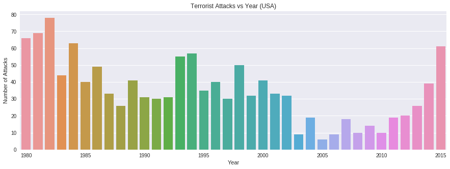

```python
# Group table by date into counts
usa_chy = gtd_table.loc[(gtd_table['country'] == 'United States') & (gtd_table['year'] >=1980)]
usa_chy = usa_chy[['year','id']].groupby(['year']).count()
usa_chy = usa_chy.rename(index=str, columns={'id':'count'})
usa_chy = usa_chy.reset_index()

# Establish ticks and labels for this type of graph
yearmin = 1980
numyears = yearmax-yearmin+1
year_labels2 = range(yearmin, yearmax+1, 5)
year_ticks2 = [5*i for i in range(int(numyears/5)+1)]

# Graph and label figure
fig, ax = plt.subplots(figsize=(15,5))
sns.barplot(x='year',y='count',data=usa_chy)
plt.title('Terrorist Attacks vs Year (USA)')
plt.ylabel('Number of Attacks')
plt.xlabel('Year')
plt.xticks(year_ticks2);
ax.set_xticklabels(year_labels2);
```

It is now easier to see the the trends of terrorist attacks in now that we've focused on specific decades. Now lets break the data down further to analyze any discrepancies among the day of the year. To do this, group the US data by the year value and count the number of lines with the same dayofyear value.

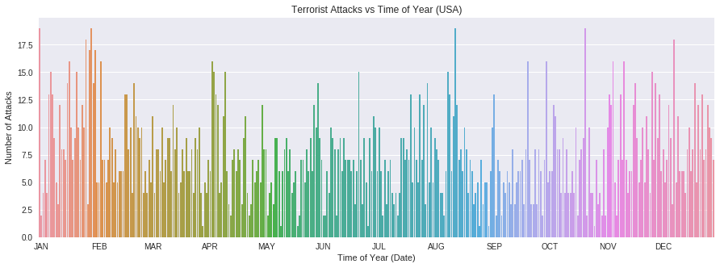

```python
# Group table by date into counts
usa_date = gtd_table.loc[gtd_table['country'] == 'United States']
usa_date = usa_date[['dayofyear','id']].groupby(['dayofyear']).count()
usa_date = usa_date.rename(index=str, columns={'id':'count'})
usa_date = usa_date.reset_index()

# plot the data
fig, ax = plt.subplots(figsize=(15,5))
sns.barplot(x='dayofyear',y='count',data=usa_date);
plt.title('Terrorist Attacks vs Time of Year (USA)')
plt.ylabel('Number of Attacks')
plt.xlabel('Time of Year (Date)')
plt.xticks(month_ticks);
ax.set_xticklabels(month_labels);
```

# IV. Insight and Conclusion

Due to a lot of last minute pivoting due to inability to access the data we were searching for we were unable to commit as much time to the project as we had hoped. Below, I will steps I planned to take moving forward:

Given a completely random selection of dates the distribution of terror attacks should be uniform across all days of the year. Seeing that there were distinct spikes in the frequency of attacks in the USA from day-to-day, I would have hypothesized that they were associated with specific events.

With more time, I would cross reference the dates with religious holidays and run statistics comparing the probability of the attacks falling on the holiday of a given religious group based on the data compared to the probability of it falling on the holiday given a random distribution.

There are several reasons why a specific religious groups may have a statistically significant portion of attacks falling on an observed holiday. One possibility is that a radicalist group within that community is a frequent source of terrorist activities. Driven by religious motivations, the observed holiday could have a spiritual significance inciting an attack seen as poetic in nature. Another possibility is that the religious group is more commonly the victim of terrorist activity. Radicalist groups may have incentive to attack on specific holidays during which people of this community are gathered together in celebration or observation. An intended message may also be the driving factor of the correlation in this case as well.

It's important to keep in mind that each day holds the sum of data from 47 years (1970-2016). From one perspective, 47 samples may be too few to draw conclusions from. Much of the variation in distribution may be explained by the low number of samples. From another perspective it may be too long of a period on which to analyze this kind of data. The data is drawn over the course of several decades, during which ideological movements may rise and fall out of fashion. To be more effective, the data may need to be further stratified using known features such as country or region and the associated demographic features of people in that region.

## References

- Global Terrorism Data: https://www.kaggle.com/START-UMD/gtd
- Pandas documentation: https://pandas.pydata.org/pandas-docs/stable/generated/pandas.DataFrame.html
- Folium documentation: https://folium.readthedocs.io/en/latest/
- Numpy Polyfit: https://docs.scipy.org/doc/numpy/reference/generated/numpy.polyfit.html
- Sckit Learn: http://scikit-learn.org/stable/modules/generated/sklearn.model_selection.KFold.html.

### Special Thanks

Thank you [John Dickerson](http://jpdickerson.com/) for teaching such a fun and exciting class!